# Machine Learning. Práctica 1

#### Realizado por: Armando Torner

## Disyuntiva

Nos encontramos muchas veces que a la hora de comprar un vino, si no lo conocemos previamente, no sabemos si va a ser bueno o malo. A menudo la gente opta por comprar un vino caro, dando por hecho que será un buen vino. Sin embargo, todos conocemos a alguien que dice saber de un vino muy bueno y a la vez barato. Nos encontramos por tanto ante una disyuntiva: ¿Son todos los vinos buenos caros?, ¿Cuanto mejor es un vino, más alto es su precio?

## Objetivos del trabajo

Queremos resolver en este caso la correlación existente entre el precio de un vino y su calidad. El precio es un dato objetivo, pero nos encontramos un problema con la calidad del vino, ya que es un dato subjetivo. Para solucionarlo, vamos a dar por válida la puntuación que otorga un experto en la materia a cada vino

Contamos con los datos de distintos vinos del mundo, entre los que se encuentran su precio, su puntuación por un experto, y otros datos que pueden ser relevantes, como la zona de procedencia, o el tipo de uva con el que se elabora. Los vinos no son todos del mismo año, primero por razones lógicas de maduración (no pasan el mismo tiempo en barrica un crianza que un reserva, por ejemplo) y segundo porque hay vinos de distintas añadas.

Los datos disponibles son vinos de distintas partes del mundo. Lógicamente hay más registros de los paises con mayor tradición vinícola, como pueden ser Francia, España, Italia o Chile. Aunque en un principio vamos a analizar todos los datos con un análisis exploratorio, para realizar el estudio en profundidad sólo vamos a tomar en consideración los vinos españoles, que son los que personalmente me interesa estudiar.

## Descripción de las variables contenidas en el dataset

**Country**: país de origen del vino

**Description**: breve descripción sobre los aromas del vino

**Designation**: viñedo del que provienen las uvas que elaboran el vino

**Points**: la cantidad de puntos con la que WineEnthusiast calificó al vino en una escala de 1-100

**Price**: es el precio de una botella de vino

**Province**: es la provincia o estado de procedencia del vino

**Region_1**: es el área vitivinícola en una provincia o estado

**Region_2**: si existe una región más específica dentro del área vitivinícola

**Taster_name**: nombre del catador del vino

**Taster_twitter_handle**: cuenta de Twitter asociada al catador del vino

**Title**: nombre del vino (incluye la añada)

**Variety**: variedad de uva empleada en la elaboracion del vino

**Winery**: la bodega que elaboró el vino

## Análisis exploratorio de los datos

### Carga de los datos

En primer lugar procedemos a cargar algunos paquetes importantes:

```python
import pandas as pd
import numpy as np
import matplotlib.pyplot as plt
%matplotlib inline
import seaborn as sns
import scipy
```

En segundo lugar procedemos a cargar el dataset:

```python
directorio_datos = 'Datos/winemag-data-130k-v2.csv'

datos_originales = pd.read_csv(directorio_datos, index_col = 0)
```

Para ver una primera aproximación a los datos, se muestran las primeras y últimas 10 filas del dataset completo. Además se verifica la carga de las variables en el tipo de variable que le corresponda.

```python
datos_originales.head(10)
```

|  | country | description | designation | points | price | province | region_1 | region_2 | taster_name | taster_twitter_handle | title | variety | winery |
| --- | --- | --- | --- | --- | --- | --- | --- | --- | --- | --- | --- | --- | --- |
| 0 | Italy | Aromas include tropical fruit, broom, brimston... | Vulkà Bianco | 87 | NaN | Sicily & Sardinia | Etna | NaN | Kerin O’Keefe | @kerinokeefe | Nicosia 2013 Vulkà Bianco (Etna) | White Blend | Nicosia |
| 1 | Portugal | This is ripe and fruity, a wine that is smooth... | Avidagos | 87 | 15.0 | Douro | NaN | NaN | Roger Voss | @vossroger | Quinta dos Avidagos 2011 Avidagos Red (Douro) | Portuguese Red | Quinta dos Avidagos |
| 2 | US | Tart and snappy, the flavors of lime flesh and... | NaN | 87 | 14.0 | Oregon | Willamette Valley | Willamette Valley | Paul Gregutt | @paulgwine | Rainstorm 2013 Pinot Gris (Willamette Valley) | Pinot Gris | Rainstorm |
| 3 | US | Pineapple rind, lemon pith and orange blossom ... | Reserve Late Harvest | 87 | 13.0 | Michigan | Lake Michigan Shore | NaN | Alexander Peartree | NaN | St. Julian 2013 Reserve Late Harvest Riesling ... | Riesling | St. Julian |
| 4 | US | Much like the regular bottling from 2012, this... | Vintner's Reserve Wild Child Block | 87 | 65.0 | Oregon | Willamette Valley | Willamette Valley | Paul Gregutt | @paulgwine | Sweet Cheeks 2012 Vintner's Reserve Wild Child... | Pinot Noir | Sweet Cheeks |
| 5 | Spain | Blackberry and raspberry aromas show a typical... | Ars In Vitro | 87 | 15.0 | Northern Spain | Navarra | NaN | Michael Schachner | @wineschach | Tandem 2011 Ars In Vitro Tempranillo-Merlot (N... | Tempranillo-Merlot | Tandem |
| 6 | Italy | Here's a bright, informal red that opens with ... | Belsito | 87 | 16.0 | Sicily & Sardinia | Vittoria | NaN | Kerin O’Keefe | @kerinokeefe | Terre di Giurfo 2013 Belsito Frappato (Vittoria) | Frappato | Terre di Giurfo |
| 7 | France | This dry and restrained wine offers spice in p... | NaN | 87 | 24.0 | Alsace | Alsace | NaN | Roger Voss | @vossroger | Trimbach 2012 Gewurztraminer (Alsace) | Gewürztraminer | Trimbach |
| 8 | Germany | Savory dried thyme notes accent sunnier flavor... | Shine | 87 | 12.0 | Rheinhessen | NaN | NaN | Anna Lee C. Iijima | NaN | Heinz Eifel 2013 Shine Gewürztraminer (Rheinhe... | Gewürztraminer | Heinz Eifel |
| 9 | France | This has great depth of flavor with its fresh ... | Les Natures | 87 | 27.0 | Alsace | Alsace | NaN | Roger Voss | @vossroger | Jean-Baptiste Adam 2012 Les Natures Pinot Gris... | Pinot Gris | Jean-Baptiste Adam |

```python
datos_originales.tail(10)
```

|  | country | description | designation | points | price | province | region_1 | region_2 | taster_name | taster_twitter_handle | title | variety | winery |
| --- | --- | --- | --- | --- | --- | --- | --- | --- | --- | --- | --- | --- | --- |
| 129961 | Italy | Intense aromas of wild cherry, baking spice, t... | NaN | 90 | 30.0 | Sicily & Sardinia | Sicilia | NaN | Kerin O’Keefe | @kerinokeefe | COS 2013 Frappato (Sicilia) | Frappato | COS |
| 129962 | Italy | Blackberry, cassis, grilled herb and toasted a... | Sàgana Tenuta San Giacomo | 90 | 40.0 | Sicily & Sardinia | Sicilia | NaN | Kerin O’Keefe | @kerinokeefe | Cusumano 2012 Sàgana Tenuta San Giacomo Nero d... | Nero d'Avola | Cusumano |
| 129963 | Israel | A bouquet of black cherry, tart cranberry and ... | Oak Aged | 90 | 20.0 | Galilee | NaN | NaN | Mike DeSimone | @worldwineguys | Dalton 2012 Oak Aged Cabernet Sauvignon (Galilee) | Cabernet Sauvignon | Dalton |
| 129964 | France | Initially quite muted, this wine slowly develo... | Domaine Saint-Rémy Herrenweg | 90 | NaN | Alsace | Alsace | NaN | Roger Voss | @vossroger | Domaine Ehrhart 2013 Domaine Saint-Rémy Herren... | Gewürztraminer | Domaine Ehrhart |
| 129965 | France | While it's rich, this beautiful dry wine also ... | Seppi Landmann Vallée Noble | 90 | 28.0 | Alsace | Alsace | NaN | Roger Voss | @vossroger | Domaine Rieflé-Landmann 2013 Seppi Landmann Va... | Pinot Gris | Domaine Rieflé-Landmann |
| 129966 | Germany | Notes of honeysuckle and cantaloupe sweeten th... | Brauneberger Juffer-Sonnenuhr Spätlese | 90 | 28.0 | Mosel | NaN | NaN | Anna Lee C. Iijima | NaN | Dr. H. Thanisch (Erben Müller-Burggraef) 2013 ... | Riesling | Dr. H. Thanisch (Erben Müller-Burggraef) |
| 129967 | US | Citation is given as much as a decade of bottl... | NaN | 90 | 75.0 | Oregon | Oregon | Oregon Other | Paul Gregutt | @paulgwine | Citation 2004 Pinot Noir (Oregon) | Pinot Noir | Citation |
| 129968 | France | Well-drained gravel soil gives this wine its c... | Kritt | 90 | 30.0 | Alsace | Alsace | NaN | Roger Voss | @vossroger | Domaine Gresser 2013 Kritt Gewurztraminer (Als... | Gewürztraminer | Domaine Gresser |
| 129969 | France | A dry style of Pinot Gris, this is crisp with ... | NaN | 90 | 32.0 | Alsace | Alsace | NaN | Roger Voss | @vossroger | Domaine Marcel Deiss 2012 Pinot Gris (Alsace) | Pinot Gris | Domaine Marcel Deiss |
| 129970 | France | Big, rich and off-dry, this is powered by inte... | Lieu-dit Harth Cuvée Caroline | 90 | 21.0 | Alsace | Alsace | NaN | Roger Voss | @vossroger | Domaine Schoffit 2012 Lieu-dit Harth Cuvée Car... | Gewürztraminer | Domaine Schoffit |

A continuación se realiza un recuento de los datos

```python
datos_originales.count()
```

```
country                  129908
description              129971
designation               92506
points                   129971
price                    120975
province                 129908
region_1                 108724
region_2                  50511
taster_name              103727
taster_twitter_handle     98758
title                    129971
variety                  129970
winery                   129971
dtype: int64
```

Vemos que hay un total de 129.971 observaciones, sin embargo hay algunas variables que presentan datos ausentes, que deberán ser tratadas posteriormente

Ahora vemos el tipo de datos que tenemos:

```python
datos_originales.dtypes
```

```
country                   object
description               object
designation               object
points                     int64
price                    float64
province                  object
region_1                  object
region_2                  object
taster_name               object
taster_twitter_handle     object
title                     object
variety                   object
winery                    object
dtype: object
```

## Primer filtrado de datos

Queremos realizar en primer lugar un filtrado de los datos para quedarnos únicamente con los vinos de origen español, que son los que queremos analizar

```python
datos_spain = datos_originales[datos_originales['country'] == 'Spain']
```

```python
datos_spain.head(10)
```

|  | country | description | designation | points | price | province | region_1 | region_2 | taster_name | taster_twitter_handle | title | variety | winery |
| --- | --- | --- | --- | --- | --- | --- | --- | --- | --- | --- | --- | --- | --- |
| 5 | Spain | Blackberry and raspberry aromas show a typical... | Ars In Vitro | 87 | 15.0 | Northern Spain | Navarra | NaN | Michael Schachner | @wineschach | Tandem 2011 Ars In Vitro Tempranillo-Merlot (N... | Tempranillo-Merlot | Tandem |
| 18 | Spain | Desiccated blackberry, leather, charred wood a... | Vendimia Seleccionada Finca Valdelayegua Singl... | 87 | 28.0 | Northern Spain | Ribera del Duero | NaN | Michael Schachner | @wineschach | Pradorey 2010 Vendimia Seleccionada Finca Vald... | Tempranillo Blend | Pradorey |
| 81 | Spain | Bland, mature aromas of white fruits are on th... | NaN | 86 | 16.0 | Galicia | Rías Baixas | NaN | Michael Schachner | @wineschach | Spyro 2014 Albariño (Rías Baixas) | Albariño | Spyro |
| 154 | Spain | Ripe aromas of raisin, black plum and horsehid... | Single Vineyard Estate Bottled | 91 | 50.0 | Central Spain | Dominio de Valdepusa | NaN | Michael Schachner | @wineschach | Marques de Griñon 2010 Single Vineyard Estate ... | Graciano | Marques de Griñon |
| 212 | Spain | Mellow white-fruit aromas are nonspecific and ... | Fermentado en Barrica | 90 | 40.0 | Northern Spain | Rueda | NaN | Michael Schachner | @wineschach | Matarromera 2015 Fermentado en Barrica Verdejo... | Verdejo | Matarromera |
| 244 | Spain | Simple but well-maded wine with aromas of chew... | Herederos de François Lurton Villafrance de Duero | 85 | 13.0 | Northern Spain | Vino de la Tierra de Castilla y León | NaN | Michael Schachner | @wineschach | J. & F. Lurton 2007 Herederos de François Lurt... | Red Blend | J. & F. Lurton |
| 287 | Spain | This is the stud in the Acústic stable. A blen... | Braó Vinyes Velles | 92 | 40.0 | Catalonia | Montsant | NaN | Michael Schachner | @wineschach | Acústic 2010 Braó Vinyes Velles Carignan-Grena... | Carignan-Grenache | Acústic |
| 339 | Spain | Red in color, with berry and apple aromas, thi... | 1887 Rosado | 82 | 13.0 | Catalonia | Cava | NaN | Michael Schachner | @wineschach | Cavas Hill NV 1887 Rosado Sparkling (Cava) | Sparkling Blend | Cavas Hill |
| 342 | Spain | Funky, yeasty aromas of cinnamon, spent lees a... | NaN | 82 | 11.0 | Catalonia | Cava | NaN | Michael Schachner | @wineschach | Bellisco NV Sparkling (Cava) | Sparkling Blend | Bellisco |
| 426 | Spain | Slightly foxy on the nose, with rubbery aromas... | Seis | 89 | 18.0 | Northern Spain | Rioja | NaN | Michael Schachner | @wineschach | Luberri 2011 Seis (Rioja) | Tempranillo | Luberri |

Realizamos nuevamente un cuenteo de los datos

```python
datos_spain.count()
```

```
country                  6645
description              6645
designation              5320
points                   6645
price                    6573
province                 6645
region_1                 6637
region_2                    0
taster_name              6581
taster_twitter_handle    6581
title                    6645
variety                  6645
winery                   6645
dtype: int64
```

Vemos que tenemos un total de 6645 observaciones de vinos españoles. A continuación vamos a realizar un análisis de algunas variables para eliminar las que no sean relevantes para nuestro estudio

Lo primero de todo, queremos que la muestra sea lo más objetiva posible. Por ello, queremos analizar los vinos que hayan sido catados por la misma persona, para evitar sesgos subjetivos de distintas personas a la hora de analizar la calidad. Vemos que la mayoría de observaciones son del crítico Michael Schachner, por lo que nos quedaremos únicamente con los vinos que haya catado él.

```python
datos_spain = datos_spain[datos_spain['taster_name'] == 'Michael Schachner']
datos_spain.count()
```

```
country                  6575
description              6575
designation              5259
points                   6575
price                    6503
province                 6575
region_1                 6567
region_2                    0
taster_name              6575
taster_twitter_handle    6575
title                    6575
variety                  6575
winery                   6575
dtype: int64
```

A continuación eliminamos algunas variables que son de poca utilidad: el nombre del crítico (es para todas las observaciones el mismo), la cuenta de Twitter del crítico, la región 2 del vino (no hay ninguna observación), la descripción del aroma (es distinto en cada vino, y absolutamente subjetivo), el viñedo de procedencia de la uva (existe muy poca homogeneidad en los datos, y no aporta por tanto información significativa), la bodega creadora del vino (queremos analizar el vino independientemente de quién lo elabore) y por último el país (ya que todos los vinos son españoles)

```python
datos_spain.drop(['country', 'description', 'designation', 'region_2', 'taster_name', 'taster_twitter_handle', 'winery'], axis='columns', inplace=True)
```

```python
datos_spain.head(10)
```

|  | points | price | province | region_1 | title | variety |
| --- | --- | --- | --- | --- | --- | --- |
| 5 | 87 | 15.0 | Northern Spain | Navarra | Tandem 2011 Ars In Vitro Tempranillo-Merlot (N... | Tempranillo-Merlot |
| 18 | 87 | 28.0 | Northern Spain | Ribera del Duero | Pradorey 2010 Vendimia Seleccionada Finca Vald... | Tempranillo Blend |
| 81 | 86 | 16.0 | Galicia | Rías Baixas | Spyro 2014 Albariño (Rías Baixas) | Albariño |
| 154 | 91 | 50.0 | Central Spain | Dominio de Valdepusa | Marques de Griñon 2010 Single Vineyard Estate ... | Graciano |
| 212 | 90 | 40.0 | Northern Spain | Rueda | Matarromera 2015 Fermentado en Barrica Verdejo... | Verdejo |
| 244 | 85 | 13.0 | Northern Spain | Vino de la Tierra de Castilla y León | J. & F. Lurton 2007 Herederos de François Lurt... | Red Blend |
| 287 | 92 | 40.0 | Catalonia | Montsant | Acústic 2010 Braó Vinyes Velles Carignan-Grena... | Carignan-Grenache |
| 339 | 82 | 13.0 | Catalonia | Cava | Cavas Hill NV 1887 Rosado Sparkling (Cava) | Sparkling Blend |
| 342 | 82 | 11.0 | Catalonia | Cava | Bellisco NV Sparkling (Cava) | Sparkling Blend |
| 426 | 89 | 18.0 | Northern Spain | Rioja | Luberri 2011 Seis (Rioja) | Tempranillo |

Ahora eliminamos los registros que tengan algún NA en cualquier variable. Para ello primero creamos un dataFrame con los datos

```python
#Creamos el dataFrame
datos_spain_df = pd.DataFrame(datos_spain, columns=['points', 'price', 'province', 'region_1', 'title', 'variety'])
```

```python
# Vemos cuantas observaciones hay de cada variable
datos_spain_df.count()
```

```
points      6575
price       6503
province    6575
region_1    6567
title       6575
variety     6575
dtype: int64
```

```python
#Convertimos las variables "points" y "price" a numéricas. Las que no pueden convertirse, se convierten en NA
datos_spain_df[['points','price']] = datos_spain_df[['points','price']].apply(pd.to_numeric)
#Eliminamos las observaciones que contengan algún NA
datos_spain_df = datos_spain_df.dropna()
```

```python
#Vemos con cuantas observaciones contamos
datos_spain_df.count()
```

```
points      6495
price       6495
province    6495
region_1    6495
title       6495
variety     6495
dtype: int64
```

```python
#Vemos que el resto de columnas no han sufrido cambios
datos_spain_df.head(10)
```

|  | points | price | province | region_1 | title | variety |
| --- | --- | --- | --- | --- | --- | --- |
| 5 | 87 | 15.0 | Northern Spain | Navarra | Tandem 2011 Ars In Vitro Tempranillo-Merlot (N... | Tempranillo-Merlot |
| 18 | 87 | 28.0 | Northern Spain | Ribera del Duero | Pradorey 2010 Vendimia Seleccionada Finca Vald... | Tempranillo Blend |
| 81 | 86 | 16.0 | Galicia | Rías Baixas | Spyro 2014 Albariño (Rías Baixas) | Albariño |
| 154 | 91 | 50.0 | Central Spain | Dominio de Valdepusa | Marques de Griñon 2010 Single Vineyard Estate ... | Graciano |
| 212 | 90 | 40.0 | Northern Spain | Rueda | Matarromera 2015 Fermentado en Barrica Verdejo... | Verdejo |
| 244 | 85 | 13.0 | Northern Spain | Vino de la Tierra de Castilla y León | J. & F. Lurton 2007 Herederos de François Lurt... | Red Blend |
| 287 | 92 | 40.0 | Catalonia | Montsant | Acústic 2010 Braó Vinyes Velles Carignan-Grena... | Carignan-Grenache |
| 339 | 82 | 13.0 | Catalonia | Cava | Cavas Hill NV 1887 Rosado Sparkling (Cava) | Sparkling Blend |
| 342 | 82 | 11.0 | Catalonia | Cava | Bellisco NV Sparkling (Cava) | Sparkling Blend |
| 426 | 89 | 18.0 | Northern Spain | Rioja | Luberri 2011 Seis (Rioja) | Tempranillo |

Ahora eliminamos los datos repetidos:

```python
datos_spain_df = datos_spain_df.drop_duplicates()
```

```python
#Vemos con cuantas observaciones contamos definitivamente
datos_spain_df.count()
```

```
points      5955
price       5955
province    5955
region_1    5955
title       5955
variety     5955
dtype: int64
```

## Resumen de los datos

A continuación vemos un esbozo de las principales medidas de las variables numéricas, así como su dispersión

```python
datos_spain_df.describe()
```

|  | points | price |
| --- | --- | --- |
| count | 5955.000000 | 5955.000000 |
| mean | 87.266163 | 28.406213 |
| std | 3.130386 | 35.172229 |
| min | 80.000000 | 4.000000 |
| 25% | 85.000000 | 13.000000 |
| 50% | 87.000000 | 18.000000 |
| 75% | 89.000000 | 30.000000 |
| max | 98.000000 | 770.000000 |

Llama la atención el dato de la desviación estandar, que es notoriamente más elevada en el precio que en la puntuación del vino.

Vemos también que la puntación de los vinos tiene como mínimo un 80. Esto implica que las diferencias numericas entre los distintos vinos es pequeña, pero una diferencia de varios puntos implica por tanto una gran diferencia en la calidad.

### Distribución de las variables

Primero analizaremos las variables categoricas, viendo su frecuencia relativa:

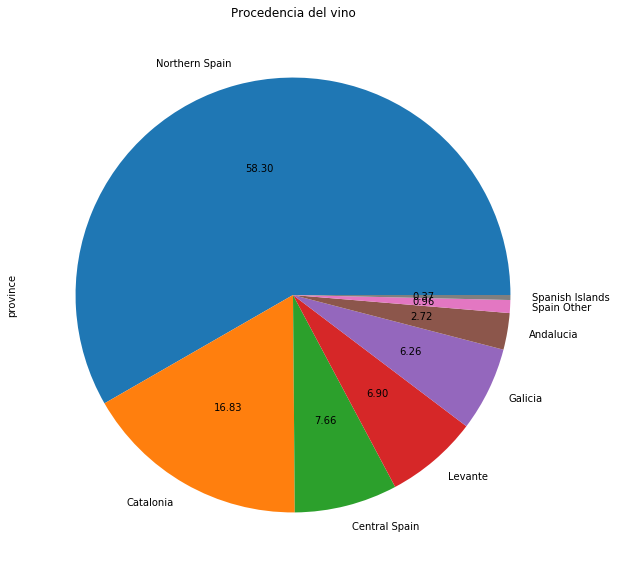

```python
# # Gráfico de tarta de frecuencias relativas.
plot = datos_spain_df['province'].value_counts().plot(kind='pie', autopct='%.2f',
                                            figsize=(10, 10),
                                            title='Procedencia del vino')
```

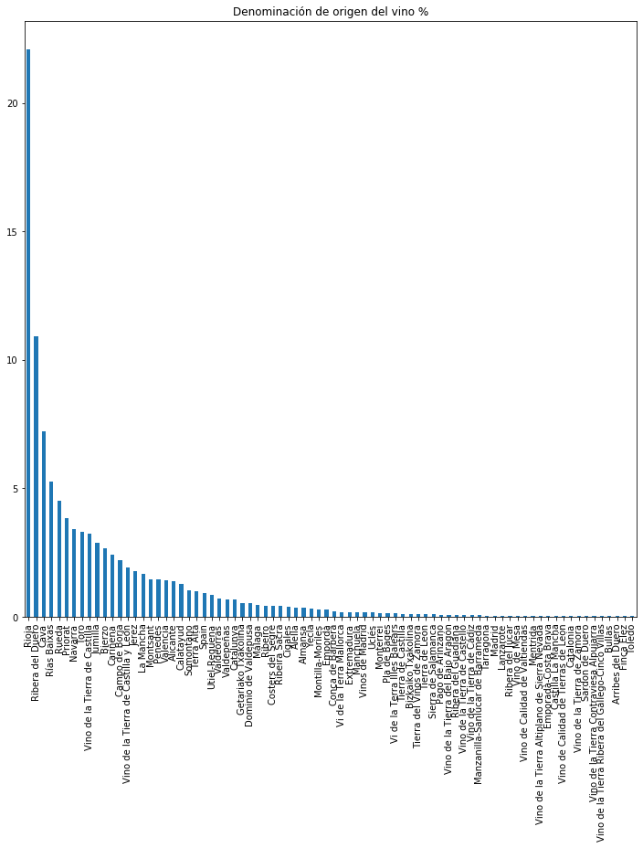

```python
# Gráfico de barras de frecuencias relativas.
plot = (100 * datos_spain_df['region_1'].value_counts() / len(datos_spain_df['region_1'])).plot(
kind='bar', title='Denominación de origen del vino %', figsize=(12, 12))
```

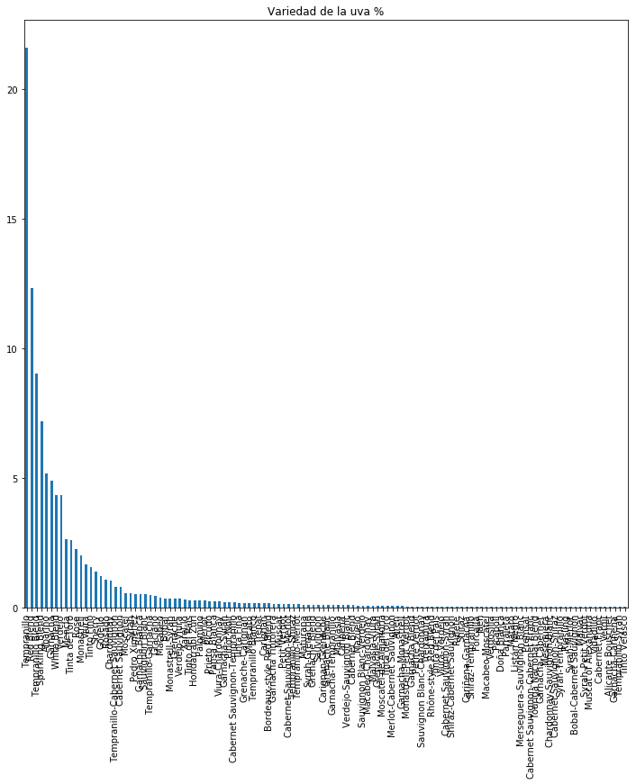

```python
# Gráfico de barras de frecuencias relativas.
plot = (100 * datos_spain_df['variety'].value_counts() / len(datos_spain_df['variety'])).plot(
kind='bar', title='Variedad de la uva %', figsize=(12, 12))
```

A continuación vemos los histogramas de las variables numéricas:

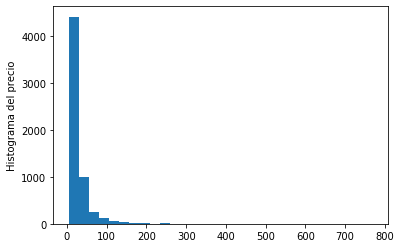

```python
# Histograma del precio
plt.hist(datos_spain_df['price'], density=False, bins=30)
plt.ylabel('Histograma del precio')
```

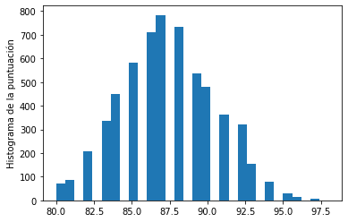

```python
# Histograma de la puntuación
plt.hist(datos_spain_df['points'], density=False, bins=30)
plt.ylabel('Histograma de la puntuación')
```

#### Breves conclusiones de la distribución de datos

Vemos claramente que la mayoría de los vinos que aparecen en esta muestra son vinos de la zona norte de España. Esto tiene mucha lógica ya que en el norte de España el clima es más propicio para la elaboración de vino

En cuanto a las denominaciones de origen, destacan por encima de las demás el Rioja y el Ribera de Duero. No sabemos si es porque la muestra ha tomado preferentemente estos tipos de vino, o si por el contrario, responde a una distribución acorde a la producción vinícola de España. No disponemos de datos para dar respuesta a esta pregunta.

En cuanto a la uva usada para la elaboración del vino, llama la atención la alta presencia de tempranillo. Es un tipo de uva tradicional de la zona de La Rioja (lo cual concuerda con las distribuciones de las denominaciones de origen), aunque se ha extendido a todo el país. Podemos concluir con las distribuciones del tipo de uva, que la mayoría de los vinos presentes en la muestra, son de variedad tinto.

En cuanto al precio, podemos concluir inequivocamente, que casi todos los datos se encuentran en la escala de 0-100 dólares. Hay algunos valores que se salen completamente de esa escala (el máximo por ejemplo se va hasta los 700 dólares), y que podrían considerarse valores atípicos. En este caso no los vamos a considerar como tal ya que no es raro encontrar vinos con un precio muy elevado, a pesar de que la mayoría tiene un precio bastante más asequible.

Llama la atención la distribución de la nota que otorga el crítico a los vinos. Claramente vemos en la gráfica que sigue una distribución normal. Tiene bastante lógica, ya que cabe suponer que hay vinos mejores, peores, y que la mayoría son vinos simplemente normales. Así podemos concluir que según este crítico, hay pocos vinos muy buenos, y pocos muy malos.

## Preparación de los datos para el análisis

Haciendo y visualizando un resumen de los datos, vemos que va a haber problemas a la hora de tratarlos y buscar correlaciones porque la mayoría son datos categóricos. Además, vemos que alguno de estos datos categóricos están muy poco homogeneizados. Es el caso de la variedad de la uva, que contiene muchas observaciones imprecisas como "Tinto fino" o "Vino de mesa". Además, esta variable está relacionada con la zona geográfica de procedencia del vino, ya que cada zona da su propia variedad de uva. Es por tanto que esta variable va a ser eliminada de la muestra.

```python
datos_spain_df.drop(['variety'], axis='columns', inplace=True)
```

```python
datos_spain_df.head(5)
```

|  | points | price | province | region_1 | title |
| --- | --- | --- | --- | --- | --- |
| 5 | 87 | 15.0 | Northern Spain | Navarra | Tandem 2011 Ars In Vitro Tempranillo-Merlot (N... |
| 18 | 87 | 28.0 | Northern Spain | Ribera del Duero | Pradorey 2010 Vendimia Seleccionada Finca Vald... |
| 81 | 86 | 16.0 | Galicia | Rías Baixas | Spyro 2014 Albariño (Rías Baixas) |
| 154 | 91 | 50.0 | Central Spain | Dominio de Valdepusa | Marques de Griñon 2010 Single Vineyard Estate ... |
| 212 | 90 | 40.0 | Northern Spain | Rueda | Matarromera 2015 Fermentado en Barrica Verdejo... |

```python
datos_vinos = datos_spain_df.loc[datos_spain_df['region_1'].isin(['Rioja', 'Ribera del Duero', 'Cava, Rias Baixas', 'Rueda', 'Toro', 'Bierzo', 'Vinos de la Tierra de Castilla y León', 'Jerez', 'La Mancha', 'Penedes', 'Valencia'])]
```

```python
datos_vinos.count()
```

```
points      2879
price       2879
province    2879
region_1    2879
title       2879
dtype: int64
```

```python
datos_vinos.head(20)
```

|  | points | price | province | region_1 | title |
| --- | --- | --- | --- | --- | --- |
| 18 | 87 | 28.0 | Northern Spain | Ribera del Duero | Pradorey 2010 Vendimia Seleccionada Finca Vald... |
| 212 | 90 | 40.0 | Northern Spain | Rueda | Matarromera 2015 Fermentado en Barrica Verdejo... |
| 426 | 89 | 18.0 | Northern Spain | Rioja | Luberri 2011 Seis (Rioja) |
| 438 | 89 | 15.0 | Northern Spain | Bierzo | Vinos de Arganza 2012 Século Mencía (Bierzo) |
| 496 | 87 | 25.0 | Northern Spain | Rueda | Loess 2009 Collection Blanco Verdejo (Rueda) |
| 500 | 87 | 11.0 | Northern Spain | Rioja | El Coto 2011 Rosado Rosé (Rioja) |
| 556 | 93 | 88.0 | Northern Spain | Ribera del Duero | Resalte 2010 Gran Resalte (Ribera del Duero) |
| 635 | 92 | 28.0 | Northern Spain | Rioja | Marqués de Murrieta 2010 Capellanía Viura (Rioja) |
| 667 | 90 | 15.0 | Levante | Valencia | Rafael Cambra 2012 Soplo Garnacha Tintorera (V... |
| 680 | 90 | 25.0 | Northern Spain | Rioja | Bodegas Berceo 2011 Selección Crianza (Rioja) |
| 754 | 87 | 10.0 | Northern Spain | Rioja | El Coto 2010 Viura (Rioja) |
| 762 | 87 | 14.0 | Northern Spain | Rueda | Oro de Castilla 2010 Solo Verdejo (Rueda) |
| 763 | 87 | 10.0 | Northern Spain | Rueda | Pablo del Villar 2010 Ipsum Verdejo-Viura (Rueda) |
| 820 | 86 | 12.0 | Northern Spain | Rioja | Navardia 2013 Made With Organic Grapes (Rioja) |
| 938 | 87 | 15.0 | Northern Spain | Rioja | Covila 2013 II Crianza (Rioja) |
| 943 | 87 | 18.0 | Northern Spain | Rioja | Finca del Marquesado 2013 Crianza (Rioja) |
| 1031 | 88 | 28.0 | Northern Spain | Ribera del Duero | Linaje Garsea 2010 Crianza (Ribera del Duero) |
| 1042 | 85 | 15.0 | Northern Spain | Rioja | Rentas de Fincas 2003 Crianza (Rioja) |
| 1053 | 85 | 30.0 | Northern Spain | Rioja | Finca La Emperatriz 2000 Reserva (Rioja) |
| 1110 | 90 | 60.0 | Northern Spain | Ribera del Duero | Casajús 2011 Antiguos Viñedos (Ribera del Duero) |

### Creación de variables dummies

Para poder tratar las variables categóricas en los siguientes cálculos, las convertimos en dummies:

```python
## Dummies para province, tomando los datos de datos_vinos
dummies_province = pd.get_dummies(datos_vinos['province']).rename(columns=lambda x: 'province_' + str(x))
df_province = pd.concat([datos_vinos, dummies_province], axis=1)
df_province = pd.DataFrame(df_province)
datos_vinos_df = df_province # Volvemos a cambiarle el nombre al dataframe
datos_vinos_df.head(10)
```

|  | points | price | province | region_1 | title | province_Andalucia | province_Central Spain | province_Levante | province_Northern Spain |
| --- | --- | --- | --- | --- | --- | --- | --- | --- | --- |
| 18 | 87 | 28.0 | Northern Spain | Ribera del Duero | Pradorey 2010 Vendimia Seleccionada Finca Vald... | 0 | 0 | 0 | 1 |
| 212 | 90 | 40.0 | Northern Spain | Rueda | Matarromera 2015 Fermentado en Barrica Verdejo... | 0 | 0 | 0 | 1 |
| 426 | 89 | 18.0 | Northern Spain | Rioja | Luberri 2011 Seis (Rioja) | 0 | 0 | 0 | 1 |
| 438 | 89 | 15.0 | Northern Spain | Bierzo | Vinos de Arganza 2012 Século Mencía (Bierzo) | 0 | 0 | 0 | 1 |
| 496 | 87 | 25.0 | Northern Spain | Rueda | Loess 2009 Collection Blanco Verdejo (Rueda) | 0 | 0 | 0 | 1 |
| 500 | 87 | 11.0 | Northern Spain | Rioja | El Coto 2011 Rosado Rosé (Rioja) | 0 | 0 | 0 | 1 |
| 556 | 93 | 88.0 | Northern Spain | Ribera del Duero | Resalte 2010 Gran Resalte (Ribera del Duero) | 0 | 0 | 0 | 1 |
| 635 | 92 | 28.0 | Northern Spain | Rioja | Marqués de Murrieta 2010 Capellanía Viura (Rioja) | 0 | 0 | 0 | 1 |
| 667 | 90 | 15.0 | Levante | Valencia | Rafael Cambra 2012 Soplo Garnacha Tintorera (V... | 0 | 0 | 1 | 0 |
| 680 | 90 | 25.0 | Northern Spain | Rioja | Bodegas Berceo 2011 Selección Crianza (Rioja) | 0 | 0 | 0 | 1 |

```python
## Dummies para region_1, tomando los datos del dataframe que acabamos de modificar
dummies_region_1 = pd.get_dummies(datos_vinos_df['region_1']).rename(columns=lambda x: 'region_1_' + str(x))
df_region_1 = pd.concat([datos_vinos_df, dummies_region_1], axis=1)
df_region_1 = pd.DataFrame(df_region_1)
datos_vinos_df = df_region_1 # Volvemos a cambiarle el nombre al dataframe
datos_vinos_df.head(10)
```

|  | points | price | province | region_1 | title | province_Andalucia | province_Central Spain | province_Levante | province_Northern Spain | region_1_Bierzo | region_1_Jerez | region_1_La Mancha | region_1_Ribera del Duero | region_1_Rioja | region_1_Rueda | region_1_Toro | region_1_Valencia |
| --- | --- | --- | --- | --- | --- | --- | --- | --- | --- | --- | --- | --- | --- | --- | --- | --- | --- |
| 18 | 87 | 28.0 | Northern Spain | Ribera del Duero | Pradorey 2010 Vendimia Seleccionada Finca Vald... | 0 | 0 | 0 | 1 | 0 | 0 | 0 | 1 | 0 | 0 | 0 | 0 |
| 212 | 90 | 40.0 | Northern Spain | Rueda | Matarromera 2015 Fermentado en Barrica Verdejo... | 0 | 0 | 0 | 1 | 0 | 0 | 0 | 0 | 0 | 1 | 0 | 0 |
| 426 | 89 | 18.0 | Northern Spain | Rioja | Luberri 2011 Seis (Rioja) | 0 | 0 | 0 | 1 | 0 | 0 | 0 | 0 | 1 | 0 | 0 | 0 |
| 438 | 89 | 15.0 | Northern Spain | Bierzo | Vinos de Arganza 2012 Século Mencía (Bierzo) | 0 | 0 | 0 | 1 | 1 | 0 | 0 | 0 | 0 | 0 | 0 | 0 |
| 496 | 87 | 25.0 | Northern Spain | Rueda | Loess 2009 Collection Blanco Verdejo (Rueda) | 0 | 0 | 0 | 1 | 0 | 0 | 0 | 0 | 0 | 1 | 0 | 0 |
| 500 | 87 | 11.0 | Northern Spain | Rioja | El Coto 2011 Rosado Rosé (Rioja) | 0 | 0 | 0 | 1 | 0 | 0 | 0 | 0 | 1 | 0 | 0 | 0 |
| 556 | 93 | 88.0 | Northern Spain | Ribera del Duero | Resalte 2010 Gran Resalte (Ribera del Duero) | 0 | 0 | 0 | 1 | 0 | 0 | 0 | 1 | 0 | 0 | 0 | 0 |
| 635 | 92 | 28.0 | Northern Spain | Rioja | Marqués de Murrieta 2010 Capellanía Viura (Rioja) | 0 | 0 | 0 | 1 | 0 | 0 | 0 | 0 | 1 | 0 | 0 | 0 |
| 667 | 90 | 15.0 | Levante | Valencia | Rafael Cambra 2012 Soplo Garnacha Tintorera (V... | 0 | 0 | 1 | 0 | 0 | 0 | 0 | 0 | 0 | 0 | 0 | 1 |
| 680 | 90 | 25.0 | Northern Spain | Rioja | Bodegas Berceo 2011 Selección Crianza (Rioja) | 0 | 0 | 0 | 1 | 0 | 0 | 0 | 0 | 1 | 0 | 0 | 0 |

### Matriz de correlaciones

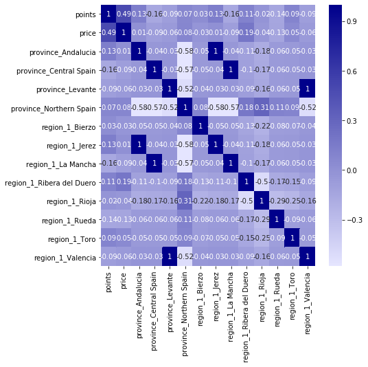

```python
matriz_corr = datos_vinos_df.corr()
plt.figure(figsize=(7,7))
sns.heatmap(round(matriz_corr, 2), annot=True, fmt=".2g",
            cmap = sns.light_palette("darkblue", as_cmap=True))
```

Podemos observar, como era previsible, que existe una alta correlación entre las variables "region_1" y las variables "province", ya que dentro de cada zona geográfica hay unas denominaciones de origen muy específicas. Vemos también la existencia de correlación entre el precio y la puntuación del vino, que era una de las cosas que se querían exxplicar en este estudio

## Modelo predictivo

A continuación vamos a realizar un modelo predictivo que trate de explicar la puntuación de un vino en función de otras variables. Comenzaremos limpiando un poco los datos:

### Limpieza de datos

Como hemos visto anteriormente, las variables "region_1" y "province" vienen a explicar lo mismo, con la diferencia de que "region_1" lo hace de forma más detallada. Es por este motivo que procedemos a la eliminación de la variables "province" así como de sus dummies

(como no deja eliminar las columnas, elimino en una tabla anterior la variable "province" y vuelvo a crear las dummies para "region_1")

```python
#Primero elimino la columna "province"
datos_vinos.drop(['province'], axis='columns', inplace=True)
datos_vinos.head(10)
```

|  | points | price | region_1 | title |
| --- | --- | --- | --- | --- |
| 18 | 87 | 28.0 | Ribera del Duero | Pradorey 2010 Vendimia Seleccionada Finca Vald... |
| 212 | 90 | 40.0 | Rueda | Matarromera 2015 Fermentado en Barrica Verdejo... |
| 426 | 89 | 18.0 | Rioja | Luberri 2011 Seis (Rioja) |
| 438 | 89 | 15.0 | Bierzo | Vinos de Arganza 2012 Século Mencía (Bierzo) |
| 496 | 87 | 25.0 | Rueda | Loess 2009 Collection Blanco Verdejo (Rueda) |
| 500 | 87 | 11.0 | Rioja | El Coto 2011 Rosado Rosé (Rioja) |
| 556 | 93 | 88.0 | Ribera del Duero | Resalte 2010 Gran Resalte (Ribera del Duero) |
| 635 | 92 | 28.0 | Rioja | Marqués de Murrieta 2010 Capellanía Viura (Rioja) |
| 667 | 90 | 15.0 | Valencia | Rafael Cambra 2012 Soplo Garnacha Tintorera (V... |
| 680 | 90 | 25.0 | Rioja | Bodegas Berceo 2011 Selección Crianza (Rioja) |

```python
# Y después creo de nuevo las dummies para "region_1"
dummies_region_1 = pd.get_dummies(datos_vinos['region_1']).rename(columns=lambda x: 'region_1_' + str(x))
df_region_1 = pd.concat([datos_vinos, dummies_region_1], axis=1)
df_region_1 = pd.DataFrame(df_region_1)
datos_vinos_prediccion = df_region_1 # Volvemos a cambiarle el nombre al dataframe
datos_vinos_prediccion.head(10)
```

|  | points | price | region_1 | title | region_1_Bierzo | region_1_Jerez | region_1_La Mancha | region_1_Ribera del Duero | region_1_Rioja | region_1_Rueda | region_1_Toro | region_1_Valencia |
| --- | --- | --- | --- | --- | --- | --- | --- | --- | --- | --- | --- | --- |
| 18 | 87 | 28.0 | Ribera del Duero | Pradorey 2010 Vendimia Seleccionada Finca Vald... | 0 | 0 | 0 | 1 | 0 | 0 | 0 | 0 |
| 212 | 90 | 40.0 | Rueda | Matarromera 2015 Fermentado en Barrica Verdejo... | 0 | 0 | 0 | 0 | 0 | 1 | 0 | 0 |
| 426 | 89 | 18.0 | Rioja | Luberri 2011 Seis (Rioja) | 0 | 0 | 0 | 0 | 1 | 0 | 0 | 0 |
| 438 | 89 | 15.0 | Bierzo | Vinos de Arganza 2012 Século Mencía (Bierzo) | 1 | 0 | 0 | 0 | 0 | 0 | 0 | 0 |
| 496 | 87 | 25.0 | Rueda | Loess 2009 Collection Blanco Verdejo (Rueda) | 0 | 0 | 0 | 0 | 0 | 1 | 0 | 0 |
| 500 | 87 | 11.0 | Rioja | El Coto 2011 Rosado Rosé (Rioja) | 0 | 0 | 0 | 0 | 1 | 0 | 0 | 0 |
| 556 | 93 | 88.0 | Ribera del Duero | Resalte 2010 Gran Resalte (Ribera del Duero) | 0 | 0 | 0 | 1 | 0 | 0 | 0 | 0 |
| 635 | 92 | 28.0 | Rioja | Marqués de Murrieta 2010 Capellanía Viura (Rioja) | 0 | 0 | 0 | 0 | 1 | 0 | 0 | 0 |
| 667 | 90 | 15.0 | Valencia | Rafael Cambra 2012 Soplo Garnacha Tintorera (V... | 0 | 0 | 0 | 0 | 0 | 0 | 0 | 1 |
| 680 | 90 | 25.0 | Rioja | Bodegas Berceo 2011 Selección Crianza (Rioja) | 0 | 0 | 0 | 0 | 1 | 0 | 0 | 0 |

A continuación nos damos cuenta de que para hacer Lasso en el futuro, vamos a tener problemas con las variables categóricas ("title" y "region_1"), por lo que vamos a crear un nuevo dataframe (datos_para_lasso) que excluya estas variables

```python
#Creamos los dos data frame separados, cada uno con variables únicamente numéricas
#Hay que hacerlo así porque da error al eliminar algunas columnas
h = datos_vinos_prediccion.iloc[:, 4:12] #Variables dummie de region_1
i = datos_vinos_prediccion.iloc[:, 0:2] #Variables que la explican (las demás)

#Juntamos los dataframe en uno solo, al que llamamos datos_para_lasso
datos_para_lasso = pd.concat([i, h], axis=1)
```

### Visualización de datos

Volvemos a ver la matriz de correlaciones:

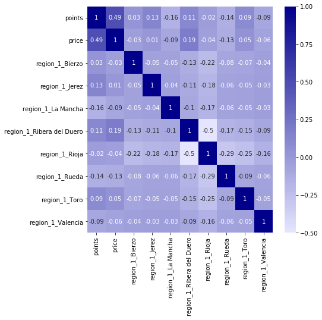

```python
matriz_corr = datos_para_lasso.corr()
plt.figure(figsize=(7,7))
sns.heatmap(round(matriz_corr, 2), annot=True, fmt=".2g",
            cmap = sns.light_palette("darkblue", as_cmap=True))
```

Y ahora graficamos la reación entre el precio y la puntuación del vino

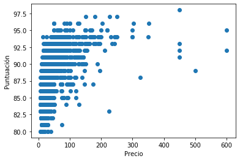

```python
plt.scatter(datos_para_lasso['price'],datos_para_lasso['points'])
plt.ylabel('Puntuación')
plt.xlabel('Precio')
```

### Datos training y datos test

Separamos los datos en training y test para realizar un modelo y poder probarlo después

```python
# Preparamos la librería
from sklearn.model_selection import train_test_split

#Creamos la división

y = datos_para_lasso.iloc[:, 0] #Variable que queremos explicar ("points")
x = datos_para_lasso.loc[:, datos_para_lasso.columns != "points"] #Variables que la explican (las demás)

#Hacemos una partición del 70% para prueba y 30% para test
x_train, x_test, y_train, y_test = train_test_split(x, y, test_size=0.3, random_state=123)

# Vemos las dimensiones de la partición
print(x_train.shape, x_test.shape, y_train.shape, y_test.shape)
```

```
(2015, 9) (864, 9) (2015,) (864,)
```

### Lasso

Procedemos a hacer un análisis de regresión con el método Lasso

```python
## Cargamos las librerías

from sklearn import linear_model
from sklearn.linear_model import LassoCV
from sklearn.datasets import make_regression
from sklearn.linear_model import LinearRegression
from sklearn.linear_model import Lasso
from sklearn.metrics import mean_squared_error
from sklearn.metrics import r2_score

## Formulamos el modelo

lassocv = LassoCV(alphas = None, cv = 10, max_iter = 100000, normalize = True)
lassocv.fit(x_train, y_train)
lassocv.alpha_

# Realizamos la regresion

model_lasso = Lasso(alpha=lassocv.alpha_) # funcion lasso
model_lasso.fit(x_train, y_train) # ajuste sobre el train
pred_lasso = model_lasso.predict(x_test) # prediccion sobre el test
print(np.sqrt(mean_squared_error(y_test,pred_lasso))) # error sobre el test
error_lasso = np.sqrt(mean_squared_error(y_test,pred_lasso))
print(r2_score(y_test, pred_lasso)) # R^2 sobre el test
```

```
2.8575574238811443
0.20175271438466624
```

Vemos que tenemos un error de 2.85 puntos a la hora de determinar la calidad del vino.

## Bibliografía

Explicaciones en clase del profesor Diego Bodas

Explicaciones en clase de la profesora Yolanda García

Foros de ayuda de StackOverFlow

Web educativa https://scikit-learn.org/

Dataset de Kaggle: https://www.kaggle.com/zynicide/wine-reviews